# Implementation of Distribuited Clustering

## Objectives

This notebook has the following objectives:

- Serve as a tutor for multi-GPU implementation using the *tensorflow* library
- To showcase how to manipulate algorithms formulations, particularly partitioning clustering, in a way that is better for distributed implementation
- Implement and discuss the formulations of K-Means algorithm

## Implementation

### Seting up the test parameters

The parameters are the values the user can chose to run this experiment in different ways. Feell free to play with them, and there are comments telling what each of the parameters do.

```python
### Data Set parameters
n_samples = 25000000 # This takes up to 8 Gb of data because of the way its handled on this tutorial
n_features = 2 # This was the chosen so we can visualize the results better
n_classes = 4 # Maximum allowed for 2d promblems
seed = 192837465

### K-means parameters
K = 4
n_max_iters = 100
```

### Libraries

The first thing we got to do is load the libraries we are going to use. The *tensorflow* and *numpy* libraries are the ones used to implement the methods, the remaining ones are used to make this notebook instructive.

```python
### Libraries for dealing with files
import os
import sys

### Reporting back to user
import time
import matplotlib.pyplot as plt
import pprint
import scipy

### Creating data sets
import numpy as np
from sklearn.datasets import make_classification

### Implementing Distribuited clustering
import tensorflow as tf
from tensorflow.python.client import device_lib
```

### Checking GPU availability

This is meant to be a multi-GPU tutorial, so for this notebook to work properly we need a multi-GPU system.

```python
def get_available_gpus():
    local_device_protos = device_lib.list_local_devices()
    return [x.name for x in local_device_protos if x.device_type == 'GPU']
```

### Creating the data sets

The skyline *make_classification* function is being used to simply this tutorial. This function can take a long time to generate the data, it will be stored in the RAM.

The optimal way to feed data into tensorflow in production is by using what is called *a tensorflow QueueRunner* or a *tf. data API*, but inputting data into *tensorflow* is a broad enough topic on its own, so it will not be discussed or implemented here (for more information check the [documentation](https://www.tensorflow.org/api_guides/python/reading_data)).

The one warning I got to give is that this shortcut can overload your RAM and freeze up your computer by using swap memory.

```python
### Generates data and saves
(X, Y) = make_classification(n_samples            = n_samples ,
                             n_features           = n_features,
                             n_informative        = n_features,
                             n_redundant          = 0         ,
                             n_classes            = n_classes ,
                             n_clusters_per_class = 1         ,
                             shuffle              = True      ,
                             random_state         = seed       )
```

### K-Means implementation

Considering a set of observations $\mathbb{X}=\{x_1,\cdots,x_m,\cdots,x_M\}$, where $x_m$ is a $n$-dimensional vector, $x_m\in\mathbb{R}^n$. The $k$-means algorithm aims at defining $K$ centers $\mu_k\in\mathbb{R}^n$ to define the $K$ clusters $\mathbb{C}_k$, such that:

\begin{equation} \mu= \arg \min W(\mathbb{X},\mu_1,\cdots,\mu_K) =\sum_{k=1}^K w(\mathbb{C}_k,\mu_k), \end{equation} where, \begin{equation} w(\mathbb{C}_k,\mu_k)=\frac{1}{2}\sum_{m\in \mathbb{C}_k} \|x_m-\mu_k\|^2. \end{equation}

The sample $x_m\in \mathbb{X}$ is assigned to its nearest center $\mu_k$, thus, $x_m \in \mathbb{C}_k$: \begin{equation} \mathbb{C}_k=\{x_m:\|x_m-\mu_k\|^2\leq \|x_m-\mu_z\|^2, \forall z\}. \end{equation}

Given that, \begin{equation} \|x_m-\mu_k\|^2 = \sum_{i=1}^n (x_{mi}-\mu_{ki})^2, \end{equation} the partial derivative of $w(\mathbb{C}_k,\mu_k)$ related to $\mu_{ki}$ is: \begin{equation} \frac{\partial w(\mathbb{C}_k,\mu_k)}{\partial \mu_{ki}} = \sum_{m\in\mathbb{C}_k} -(x_{mi}-\mu_{ki}). \end{equation}

It is worth noticing that: \begin{equation} \frac{\partial w(\mu_k)}{\partial \mu_{ji}} = 0, \forall j=1\cdots,K; j\neq k. \end{equation}

Making the gradient of $w(\mathbb{C}_k,\mu_k)$ equal to zero, $\nabla_{\mu_k} w(\mathbb{C}_k,\mu_k) = 0$, given that the gradient of the sum is the sum of the gradients, the following is obtained: \begin{eqnarray} \sum_{m\in\mathbb{C}_k} -(x_{mi}-\mu_{ki})&=&0, \forall i= 1, \cdots, M;\\ \mu_k &=& \bar{x}_m, \forall x\in\mathbb{C}_k. \end{eqnarray}

The update formula for the center $\mu_k$ can be written as: \begin{eqnarray} \mu_{ki(t+1)}&=&\mu_{ki}-\frac{1}{|\mathbb{C}_k|}\frac{\partial w(\mu_k)}{\partial \mu_{ki}}\\ &=& \mu_{ki}+\frac{1}{|\mathbb{C}_k|}\sum_{m\in\mathbb{C}_k} (x_{mi}-\mu_{ki})\\ &=& \frac{1}{|\mathbb{C}_k|} \sum_{m\in\mathbb{C}_k} x_{mi}; \end{eqnarray} thus, \begin{equation} \mu_{k(t+1)}= \bar{x}_k, \end{equation}

Where $\mu_{ki(t+1)}$ is the center in the following interaction, and, $\bar{x}_k$ is the centroid of the samples which belong to the cluster $k$.

To expand this formulation to a multi-GPU setting there is a need to split the computations in a balanced manner. Splitting the dataset between $\mathbb{X}$ into $J$ subsets $\mathbb{X}_{(j)}\subset\mathbb{X}$. \begin{eqnarray} \bigcup_{j=1}^J \mathbb{X}_{(j)} = \mathbb{X}, \\ \mathbb{X}_{(j)}\cap \mathbb{X}_{(j')} = \emptyset, \forall j\neq j'. \end{eqnarray}

The sample $x_{m(j)}\in \mathbb{X}_j$ is assigned to its nearest center $\mu_k$, thus, $x_{m(j)} \in \mathbb{C}_k$: \begin{equation}\label{eq.clusterdistributed} \mathbb{C}_{k(j)}=\{x_{m(j)}:\|x_{m(j)}-\mu_k\|^2\leq \|x_m-\mu_z\|^2, \forall z\}. \end{equation}

Thus, the error function can be written as: \begin{eqnarray} W(\mathbb{X},\mu) = \sum_{k=1}^K\sum_{j=1}^J w(\mathbb{C}_{k(j)},\mu),\\ w(\mathbb{C}_k,\mu) = \sum_{j=1}^J w(\mathbb{C}_{k(j)},\mu). \end{eqnarray}

The partial derivative of $w(\mathbb{C}_k,\mu_k)$ related to $\mu_{ki}$ is: \begin{equation}\label{eq.derivativedistributed} \frac{\partial w(\mathbb{C}_k,\mu_k)}{\partial \mu_{ki}} = \sum_{j=1}^J\sum_{m\in\mathbb{C}_{k(j)}} -(x_{mi}-\mu_{ki}). \end{equation}

Making the derivative equal to zero leads to: \begin{eqnarray} \mu_{ki} \sum_{j=1}^J|\mathbb{C}_{k(j)}| = \sum_{j=1}^J\bar{x}_{k(j)}|\mathbb{C}_{k(j)}|,\\ \mu_{ki} = \frac{\displaystyle \sum_{j=1}^J\bar{x}_{k(j)}|\mathbb{C}_{k(j)}|}{|\mathbb{C}_k|}, \end{eqnarray}

Which is a weighted sum of the centers defined by each GPU ($\bar{x}_{k(j)}$), weighted by the number of samples on that cluster ($|\mathbb{C}_{k(j)}|$).

Therefore, the only information that needs to be shared among GPUs are their desired center ($\bar{x}_{k(j)}$), and how many points ($|\mathbb{C}_{k(j)}|$) it represents.

```python
def distribuited_k_means(X, K, GPU_names, initial_centers, n_max_iters):
    setup_ts = time.time()
    number_of_gpus = len(GPU_names)
    n_points = X.shape[0]

    X_list = np.split( X[ (n_points % number_of_gpus)  :, : ], number_of_gpus )

    partial_directions = []
    partial_values = []
    partial_results = []

    config = tf.ConfigProto( log_device_placement = True, allow_soft_placement = True )
    config.gpu_options.allow_growth = True
    config.gpu_options.allocator_type = 'BFC'
    sess = tf.Session( config = config )

    with tf.name_scope('global'):
        with tf.device('/cpu:0'):
            global_centroids = tf.Variable(initial_centers)

    initialization_ts = time.time()
    sess.run(tf.global_variables_initializer())
    initialization_time = float( time.time() - initialization_ts )

    for GPU_num in range(len(GPU_names)):
        GPU_name = GPU_names[GPU_num]

        (X_mat) = X_list[GPU_num]
        (N, M) = X_mat.shape

        with tf.name_scope('scope_' + str(GPU_num)):
            with tf.device(GPU_name) :
                ####
                # In the coments we denote :
                # => N = Number of Observations
                # => M = Number of Dimensions
                # => K = Number of Centers
                ####

                # Data for GPU GPU_num to Clusterize
                X = tf.constant(X_mat)

                # Reshapes rep_centroids and rep_points to format N x K x M so that
                # the 2 matrixes have the same size
                rep_centroids = tf.reshape(tf.tile(global_centroids, [N, 1]), [N, K, M])
                rep_points = tf.reshape(tf.tile(X, [1, K]), [N, K, M])

                # Calculates sum_squares, a matrix of size N x K
                # This matrix is not sqrt((X-Y)^2), it is just(X-Y)^2
                # Since we need just the argmin(sqrt((X-Y)^2)) wich is equal to
                # argmin((X-Y)^2), it would be a waste of computation
                sum_squares = tf.reduce_sum(tf.square(tf.subtract( rep_points, rep_centroids) ), axis = 2)

                # Use argmin to select the lowest-distance point
                # This gets a matrix of size N x 1
                best_centroids = tf.argmin(sum_squares, axis = 1)

                means = []
                for c in range(K):
                    means.append(
                        tf.reduce_mean(
                            tf.gather(X, tf.reshape(tf.where(tf.equal(best_centroids, c)), [1,-1])), axis=[1]))

                new_centroids = tf.concat(means, 0)

            with tf.device('/cpu:0'):
                y_count = tf.cast(
                    tf.bincount(tf.to_int32(best_centroids), maxlength = K, minlength = K), dtype = tf.float64)

                partial_mu =  tf.multiply( tf.transpose(new_centroids), y_count )

                partial_directions.append( y_count )
                partial_values.append( partial_mu )

    with tf.name_scope('global') :
        with tf.device('/cpu:0') :
            sum_direction = tf.add_n( partial_directions )
            sum_mu = tf.add_n( partial_values )

            rep_sum_direction = tf.reshape(tf.tile(sum_direction, [M]), [M, K])
            new_centers = tf.transpose( tf.div(sum_mu, rep_sum_direction) )

            update_centroid = tf.group( global_centroids.assign(new_centers) )

    setup_time = float( time.time() - setup_ts )

    computation_time = 0.0
    for i in range(n_max_iters):
        aux_ts = time.time()
        [result, _] = sess.run([global_centroids, update_centroid])
        computation_time += float(time.time() - aux_ts)

    end_resut = {   'n_points'            : n_points                  ,
                    'avg_iter_time'       : computation_time/n_points ,
                    'n_iter'              : i+1                       ,
                    'setup_time'          : setup_time                ,
                    'initialization_time' : initialization_time       ,
                    'computation_time'    : computation_time          ,
                    'init_center'         : initial_centers           ,
                    'end_center'          : result
                }

    return end_resut
```

## Tests

We now have all that is needed to test our implementation.

#### Initial data set

The initial data set is the following:

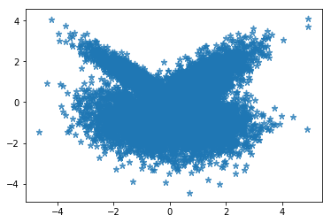

```python
plt.scatter(x      = X[0:np.min([X.shape[0], 10000]), 0] ,
            y      = X[0:np.min([X.shape[0], 10000]), 1] ,
            alpha  = 0.8                                 ,
            marker = (5, 2)                               )
plt.show()
```

#### Clustering

Running the K-Means implemented fuction as follows:

```python
initial_centers = X[0:K, :]
GPU_names = get_available_gpus()
run_result = distribuited_k_means(X               = X              ,
                                  K               = K              ,
                                  GPU_names       = GPU_names      ,
                                  n_max_iters     = n_max_iters    ,
                                  initial_centers = initial_centers )
```

##### Results

Produces the following results

```python
print ('n_points = ', np.round(run_result['n_points'], 4))
print ('avg_iter_time = ', np.round(run_result['avg_iter_time'], 4))
print ('n_iter = ', np.round(run_result['n_iter'], 4))
```

```
n_points =  25000000
avg_iter_time =  0.0
n_iter =  100
```

##### Clustered data set

That means the original data set was clustered on the following groups

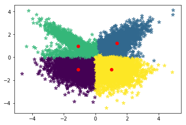

```python
dist_matrix = scipy.spatial.distance.cdist(XA     = X[0:np.min([X.shape[0], 10000]), :],
                                           XB     = run_result['end_center']           ,
                                           metric ='euclidean'                          )
closest_clust = np.argmin(dist_matrix, axis = 1)

plt.scatter(x      = X[0:np.min([X.shape[0], 10000]), 0] ,
            y      = X[0:np.min([X.shape[0], 10000]), 1] ,
            c      = closest_clust                       ,
            alpha  = 0.8                                 ,
            marker = (5, 2)                               )

plt.scatter(x      = run_result['end_center'][:, 0],
            y      = run_result['end_center'][:, 1],
            alpha  = 1                             ,
            c      = 'red'                         ,
            marker = (5, 3)                         )
plt.show()
```

## Information

It is important to note that this was implemented using *python 3.6.4* and *tensorflow 1.10.1*. And the code was tested on a system with two NVIDIA-1080Ti

And that the theoretical work is not my own.